# Trends in Human Papillomavirus (HPV) Vaccination in the United States, 2013-2023

### Question #3: Total Number of HPV Vaccines Received

```r
q3count1 <- count(nhanes_all, DataCycle, name = 'TotalParticipants')

q3stats <- q3count1 |>
  left_join(results1count2, by = 'DataCycle') |>
  left_join(q1count1, by = 'DataCycle')
head(q3stats)
```

```
  DataCycle TotalParticipants EligibleSubjects VaccinatedSubjects
1 2013-2014             10175             6019                877
2 2015-2016              9971             5780                966
3 2017-2020             15560             8855               1754
4 2021-2023             11933             5347               1732
```

```r
q3summary <- allhpvsubjects |>
  select(DataCycle, Gender, TotalShots, HPVComplete) |>
  tbl_summary(by = DataCycle) |>
  modify_caption("**Question #3: How many doses of the vaccine have you received?**") |>
  bold_labels()
q3summary
```

**Question #3: How many doses of the vaccine have you received?**

| **Characteristic** | **2013-2014** N = 877<sup>1</sup> | **2015-2016** N = 966<sup>1</sup> | **2017-2020** N = 1,754<sup>1</sup> | **2021-2023** N = 1,732<sup>1</sup> |
| --- | --- | --- | --- | --- |
| Gender |  |  |  |  |
| Male | 277 (32%) | 348 (36%) | 695 (40%) | 637 (37%) |
| Female | 600 (68%) | 618 (64%) | 1,059 (60%) | 1,095 (63%) |
| TotalShots |  |  |  |  |
| 1 Dose | 180 (21%) | 215 (22%) | 437 (25%) | 387 (22%) |
| 2 Doses | 162 (18%) | 192 (20%) | 461 (26%) | 720 (42%) |
| 3 Doses | 481 (55%) | 470 (49%) | 637 (36%) | 418 (24%) |
| Don't know | 54 (6.2%) | 89 (9.2%) | 218 (12%) | 206 (12%) |
| Refused | 0 (0%) | 0 (0%) | 1 (<0.1%) | 1 (<0.1%) |
| HPVComplete |  |  |  |  |
| Complete | 562 (65%) | 559 (59%) | 866 (51%) | 798 (47%) |
| Incomplete | 303 (35%) | 387 (41%) | 846 (49%) | 892 (53%) |
| Unknown | 2 (0.2%) | 1 (0.1%) | 2 (0.1%) | 2 (0.1%) |
| Unknown | 10 | 19 | 40 | 40 |

<sup>1</sup> n (%)

```r
# Created q3stats table to display proportions of total, eligible, and vaccinated participants; created q3summary statistical summary to review question #3 data.
```

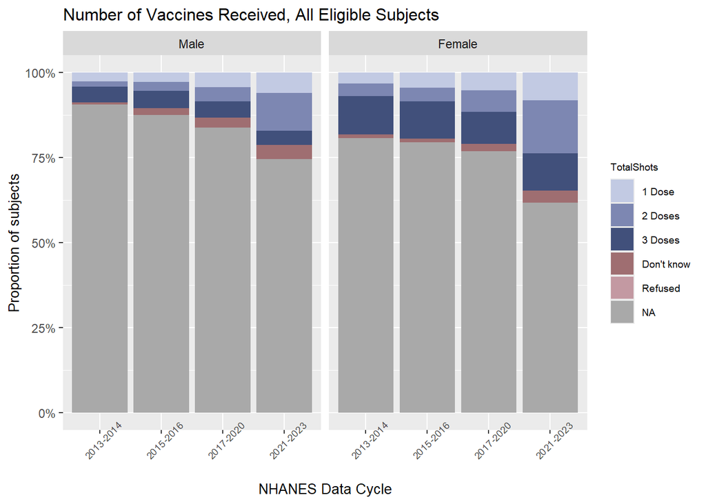

```r
ggplot(nhanes_hpv_eligible, aes(x = DataCycle, fill = TotalShots)) +
  geom_bar(position = "fill") +
  labs(title = "Number of Vaccines Received, All Eligible Subjects") +
  labs(x = "NHANES Data Cycle", y = "Proportion of subjects") +
  scale_y_continuous(labels = percent) +
  theme(title = element_text(size = 10),
        axis.text.x = element_text(angle = 45, size= 7),
        legend.title = element_text(size = 7),
        legend.text = element_text(size = 7)) +
  scale_fill_paletteer_d("MetBrewer::Monet", direction = -1, na.value =
  "darkgray") +
  facet_grid(. ~ Gender)
```

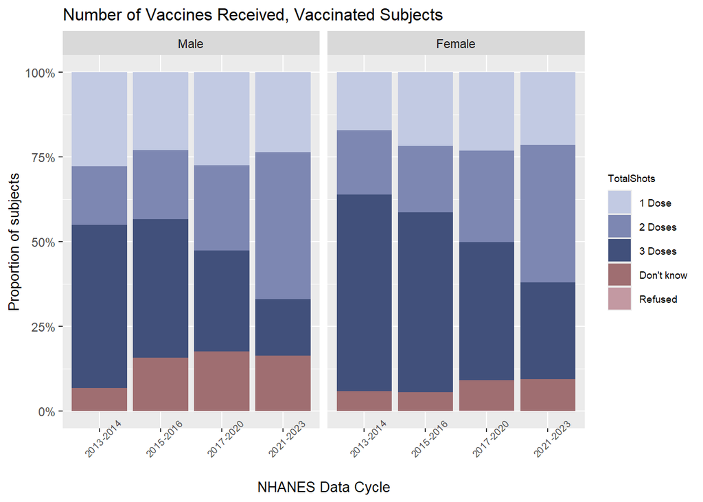

```r
ggplot(data=subset(nhanes_hpv_eligible, !is.na(TotalShots)), aes(x = DataCycle, fill = TotalShots)) +
  geom_bar(position = "fill") +
  labs(title = "Number of Vaccines Received, Vaccinated Subjects") +
  labs(x = "NHANES Data Cycle", y = "Proportion of subjects") +
  scale_y_continuous(labels = percent) +
  theme(title = element_text(size = 10),
        axis.text.x = element_text(angle = 45, size= 7),
        legend.title = element_text(size = 7),
        legend.text = element_text(size = 7)) +
  scale_fill_paletteer_d("MetBrewer::Monet", direction = -1, na.value =
  "darkgray") +
  facet_grid(. ~ Gender)
```

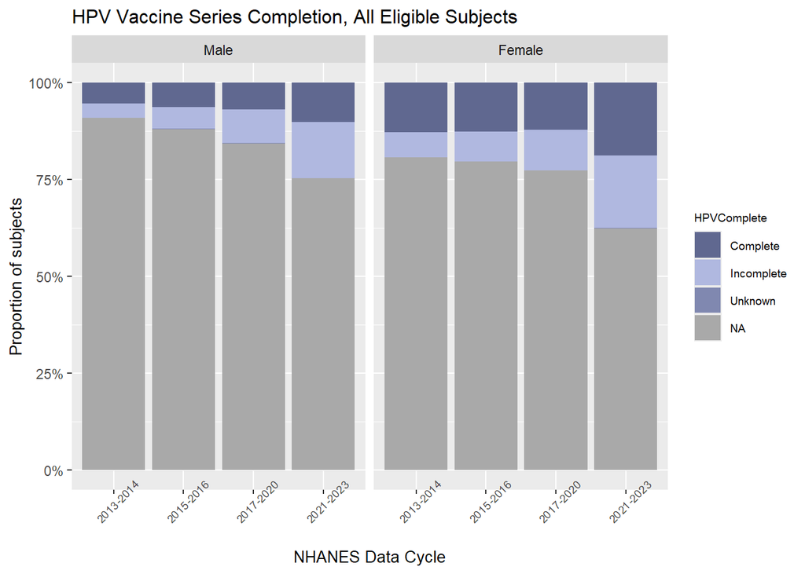

```r
#Created two plots to show total number of vaccines received in the entire eligible population versus the vaccinated population-- this provides a visual to accompany the previous statistics summary table and emphasizes a relatively small vaccinated subject population.

ggplot(nhanes_hpv_eligible, aes(x = DataCycle, fill = HPVComplete)) +
  geom_bar(position = "fill") +
  labs(title = "HPV Vaccine Series Completion, All Eligible Subjects") +
  labs(x = "NHANES Data Cycle", y = "Proportion of subjects") +
  scale_y_continuous(labels = percent) +
  theme(title = element_text(size = 10),
        axis.text.x = element_text(angle = 45, size= 7),
        legend.title = element_text(size = 7),
        legend.text = element_text(size = 7)) +
  scale_fill_paletteer_d("palettetown::poliwrath", na.value = "darkgray") +
  facet_grid(. ~ Gender)
```

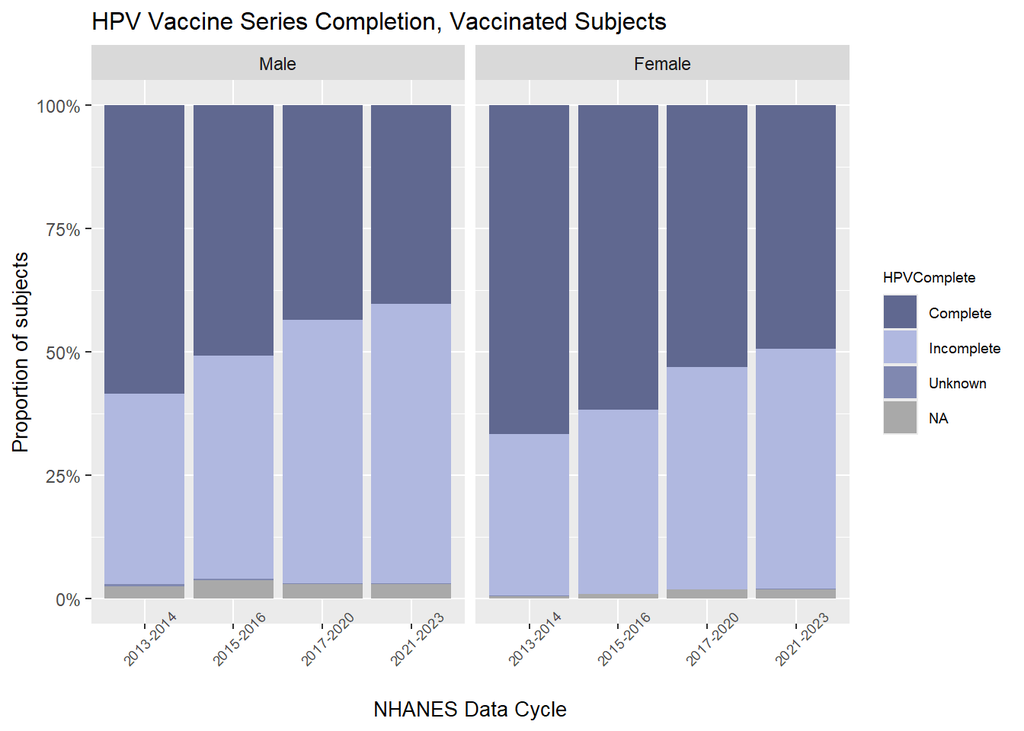

```r
ggplot(data=subset(nhanes_hpv_eligible, !is.na(TotalShots)), aes(x = DataCycle, fill = HPVComplete)) +
  geom_bar(position = "fill") +
  labs(title = "HPV Vaccine Series Completion, Vaccinated Subjects") +
  labs(x = "NHANES Data Cycle", y = "Proportion of subjects") +
  scale_y_continuous(labels = percent) +
  theme(title = element_text(size = 10),
        axis.text.x = element_text(angle = 45, size= 7),
        legend.title = element_text(size = 7),
        legend.text = element_text(size = 7)) +
  scale_fill_paletteer_d("palettetown::poliwrath", na.value = "darkgray") +
  facet_grid(. ~ Gender)
```

```r
#Created two plots again to show total number of vaccines received in the entire eligible population versus the vaccinated population.
```

```r
hpv_completeness <- filter(nhanes_hpv_eligible, HPVComplete == "Complete" |          HPVComplete == "Incomplete") |>
  droplevels()

# Created table specifically to run logistic regression on HPV series completion as a binary outcome.

levels(hpv_completeness$HPVComplete)
```

```
[1] "Complete"   "Incomplete"
```

```r
levels(hpv_completeness$DataCycle)
```

```
[1] "2013-2014" "2015-2016" "2017-2020" "2021-2023"
```

```r
levels(hpv_completeness$Gender)
```

```
[1] "Male"   "Female"
```

```r
# Checked levels to confirm intercept values.

summary((glm(HPVComplete ~ DataCycle, data = hpv_completeness, family = binomial())))
```

```
Call:
glm(formula = HPVComplete ~ DataCycle, family = binomial(), data = hpv_completeness)

Coefficients:
                   Estimate Std. Error z value Pr(>|z|)
(Intercept)        -0.61777    0.07127  -8.668  < 2e-16 ***
DataCycle2015-2016  0.25004    0.09722   2.572   0.0101 *
DataCycle2017-2020  0.59440    0.08612   6.902 5.12e-12 ***
DataCycle2021-2023  0.72913    0.08634   8.445  < 2e-16 ***
---
Signif. codes:  0 '***' 0.001 '**' 0.01 '*' 0.05 '.' 0.1 ' ' 1

(Dispersion parameter for binomial family taken to be 1)

    Null deviance: 7202.3  on 5212  degrees of freedom
Residual deviance: 7111.1  on 5209  degrees of freedom
AIC: 7119.1

Number of Fisher Scoring iterations: 4
```

```r
summary((glm(HPVComplete ~ Gender, data = hpv_completeness, family = binomial())))
```

```
Call:
glm(formula = HPVComplete ~ Gender, family = binomial(), data = hpv_completeness)

Coefficients:
             Estimate Std. Error z value Pr(>|z|)
(Intercept)   0.10045    0.04603   2.183   0.0291 *
GenderFemale -0.37444    0.05784  -6.473 9.58e-11 ***
---
Signif. codes:  0 '***' 0.001 '**' 0.01 '*' 0.05 '.' 0.1 ' ' 1

(Dispersion parameter for binomial family taken to be 1)

    Null deviance: 7202.3  on 5212  degrees of freedom
Residual deviance: 7160.3  on 5211  degrees of freedom
AIC: 7164.3

Number of Fisher Scoring iterations: 3
```

```r
summary((glm(HPVComplete ~ DataCycle + Gender, data = hpv_completeness, family = binomial())))
```

```
Call:
glm(formula = HPVComplete ~ DataCycle + Gender, family = binomial(),
    data = hpv_completeness)

Coefficients:
                   Estimate Std. Error z value Pr(>|z|)
(Intercept)        -0.37601    0.08144  -4.617 3.90e-06 ***
DataCycle2015-2016  0.23648    0.09757   2.424   0.0154 *
DataCycle2017-2020  0.56899    0.08648   6.579 4.73e-11 ***
DataCycle2021-2023  0.71474    0.08664   8.250  < 2e-16 ***
GenderFemale       -0.35646    0.05837  -6.107 1.02e-09 ***
---
Signif. codes:  0 '***' 0.001 '**' 0.01 '*' 0.05 '.' 0.1 ' ' 1

(Dispersion parameter for binomial family taken to be 1)

    Null deviance: 7202.3  on 5212  degrees of freedom
Residual deviance: 7073.7  on 5208  degrees of freedom
AIC: 7083.7

Number of Fisher Scoring iterations: 4
```

```r
# Ran logistic regression models for HPV series completion as outcome and data cycle, gender, and combined data cycle/gender as predictors.
```

Nonetheless, it is important to consider this data in the context of the larger eligible NHANES subject population. As shown in the plots for question #3 responses within the entire eligible subject cohort, the proportion of subjects reporting HPV vaccination consistently remains under 50%. As such, there are likely limitations to accuracy and the ability to make meaningful conclusions about trends in number of doses and vaccine series completion, given the relatively small size of this group.

## Conclusion

With these observations in mind, there are several recommendations for ongoing and future clinical practice, and efforts to increase HPV vaccination among all patients:

- Continue efforts to promote HPV vaccination in pediatric, gynecologic, and adult primary care settings, including discussion of benefits and importance of vaccination regardless of sex or gender.
- Further research into HPV-related outcomes in patients who receive their first HPV vaccine prior to age 9, in order to inform an official statement and recommendations from ACIP/CDC, as vaccination in patients younger than age 9 has increased over the past decade.
- Prioritize efforts to complete follow-up care and to close gaps related to care disruption and incompleteness– for example, missing and incomplete HPV vaccination due to COVID-19 related care disruption.
- Encourage patients’ access, knowledge, and understanding of personal health data, including immunization history. This has the potential to improve as electronic health records continue to become more comprehensive, interoperable, and accessible; however, ensuring that patients and providers alike have complete personal health information remains a challenge, especially with patients who access care at multiple practices and health systems.

HPV vaccination is a crucial preventative healthcare intervention with demonstrated efficacy against HPV and its serious complications, including cancer. By analyzing nationally-representative NHANES data from 2013 to 2023, we can better understand how vaccination practices and trends have evolved, and identify potential interventions to increase vaccination and series completion in all patients.

## Acknowledgements

I would like to thank Dr. Blanca Himes, Anastasia Lucas, and Jakob Woerner for their guidance and feedback in navigating R, RStudio, GitHub, and NHANES.

I would also like to thank Dr. Maria Pellecchia, Dr. Don Baag, Dr. Elaina Tully, Dr. Sig Larson, and John Laury CRNP for providing valuable insight into clinician experiences with HPV vaccination in the primary care and family medicine settings, which greatly contributed to understanding the context of this project’s data and findings.

## References

1. DeKloe, J., Urdang, Z. D., Martinez Outschoorn, U. E., & Curry, J. M. (2024). Effects of HPV vaccination on the development of HPV-related cancers: A retrospective analysis of a United States-based cohort.
2. Centers for Disease Control and Prevention. *Quadrivalent Human Papillomavirus Vaccine: Recommendations of the Advisory Committee on Immunization Practices (ACIP)*. MMWR Early Release 2007;56(RR-12): 1–23.
3. Centers for Disease Control and Prevention. *FDA Licensure of Quadrivalent Human Papillomavirus Vaccine (HPV4, Gardasil) for Use in Males and Guidance from the Advisory Committee on Immunization Practices (ACIP)*. MMWR Morbidity and Mortality Weekly Report 2010;59(20): 630–632.
4. Meites E, Kempe A, Markowitz LE. *Use of a 2-Dose Schedule for Human Papillomavirus Vaccination — Updated Recommendations of the Advisory Committee on Immunization Practices*. MMWR Morbidity and Mortality Weekly Report 2016;65: 1405–1408.
5. Meites E, Szilagyi PG, Chesson HW, Unger ER, Romero JR, Markowitz LE. *Human Papillomavirus Vaccination for Adults: Updated Recommendations of the Advisory Committee on Immunization Practices*. MMWR Morbidity and Mortality Weekly Report 2019;68: 698–702.
6. Ellingson, M. K., Sheikha, H., Nyhan, K., Oliveira, C. R., & Niccolai, L. M. (2023). Human papillomavirus vaccine effectiveness by age at vaccination: A systematic review. *Human vaccines & immunotherapeutics*, 19(2), 2239085.
7. Centers for Disease Control and Prevention. (2024). *Brief overview of sample design, nonresponse bias assessment, and analytic guidelines for NHANES August 2021-August 2023*. Centers for Disease Control and Prevention. https://wwwn.cdc.gov/nchs/nhanes/continuousnhanes/overviewbrief.aspx?Cycle=2021-2023
8. Centers for Disease Control and Prevention. (2024). *SAS Viewer*. Centers for Disease Control and Prevention. https://wwwn.cdc.gov/nchs/nhanes/SasViewer.aspx